# scRNA-seq QC Report

My Sample | Human

20 April 2026

## Summary

[output not shown]

> **Tissue context:** General defaults for mixed or unlisted tissue types.  
> UMI thresholds for `general`: PASS >= 2,000 | REVIEW >= 800

## Cell calling

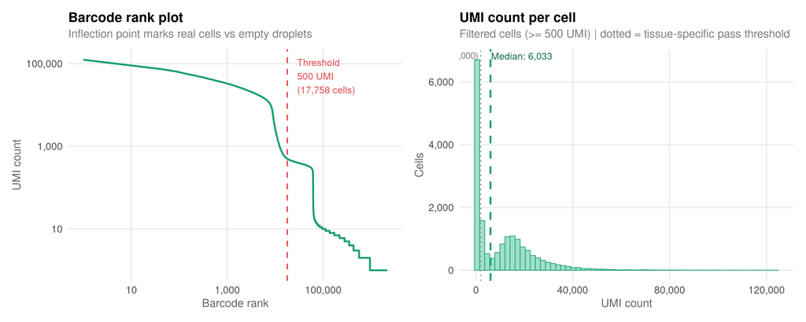

The barcode rank plot shows UMI counts from highest to lowest. The inflection separates real cells from empty droplets. A threshold of **500 UMI** was applied, yielding **17,758 cells**.

Cell count and UMI statistics at each threshold

| UMI threshold | Cells | Median UMI | Mean UMI |
| --- | --- | --- | --- |
| 100 | 61,326 | 395.0 | 3,387 |
| 200 | 60,987 | 395.0 | 3,405 |
| 500 | 17,758 | 6,033.0 | 10,803 |
| 1,000 | 12,275 | 14,009.0 | 15,339 |
| 2,000 | 10,464 | 15,711.5 | 17,751 |
| 5,000 | 9,075 | 17,132.0 | 19,989 |

## Duplication and PCR quality

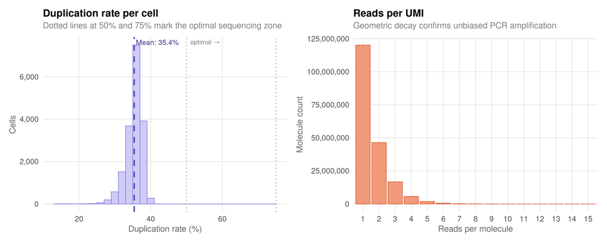

The **duplication rate** (1 - unique UMIs / total reads) measures the fraction of reads that are PCR copies of molecules already counted. A narrow, symmetric distribution indicates uniform sequencing depth and unbiased PCR amplification. The optimal zone (50-75%) is marked by dotted lines.

The **reads-per-UMI** plot shows the molecule-level read support distribution. A geometric decay (each bar ~3x smaller than the previous) confirms no PCR jackpotting or amplification bias.

## Library saturation and top-up estimate

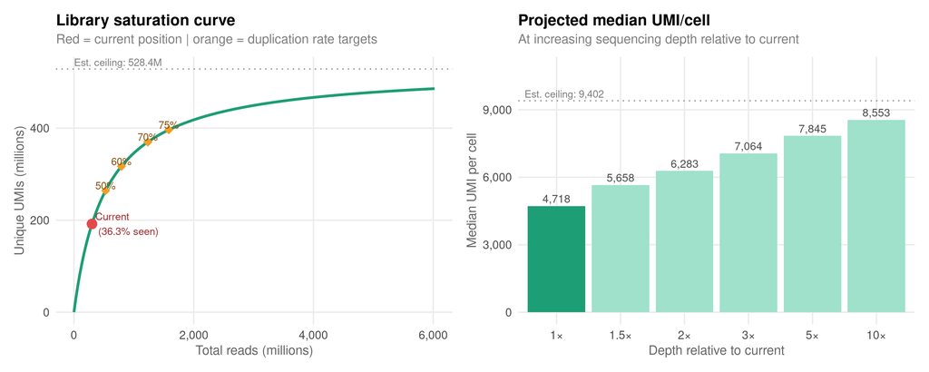

Library size is estimated using the Michaelis-Menten model: `est_library = observed_UMIs / duplication_rate`. This assumes uniform sampling probability — highly expressed genes are near-complete while rare transcripts make up most of the unseen fraction.

Reads required to reach each duplication rate target

| Target dup rate | Total reads needed (M) | Fold increase | Projected median UMI/cell |
| --- | --- | --- | --- |
| 50% | 528 | 1.8 | 6005 |
| 60% | 793 | 2.6 | 6827 |
| 70% | 1,233 | 4.1 | 7567 |
| 75% | 1,585 | 5.3 | 7910 |

## Recommendation

### Top-up sequencing recommended

**Current duplication rate:** 35.4% (below the 50% optimal threshold).  
**Implication:** The library is under-sequenced relative to its complexity. Only 36.3% of the estimated 528,434,951 molecule library has been observed.  
**Library quality:** The narrow duplication rate distribution and geometric reads-per-UMI decay confirm this is a sequencing depth issue — not a library preparation or PCR quality issue.  
**Action:** Request a **1.8x top-up run** on the existing library. No new library preparation is needed.

| Target dup rate | Total reads needed (M) | Fold increase | Projected median UMI/cell |
| --- | --- | --- | --- |
| 50% | 528 | 1.8x | 6,005 |
| 60% | 793 | 2.6x | 6,827 |
| 70% | 1,233 | 4.1x | 7,567 |
| 75% | 1,585 | 5.3x | 7,910 |

> **Note on the saturation model:** Estimates assume equal sampling probability across all molecules. In reality, highly expressed genes are already near-completely sampled; the unseen fraction (3,369 UMI/cell) is enriched for lowly expressed transcripts. Top-up sequencing disproportionately benefits detection of rare or lowly expressed genes.

*Generated by scrna_qc_report.R | 2026-04-20 11:57*